# Progressives Morphosyntactic Analysis of Textbook Conversation

Elen Le Foll

09/05/2019

This script is part of the Online Appendix to my PhD thesis.

Please cite as: Le Foll, Elen. 2022. Textbook English: A Corpus-Based Analysis of the Language of EFL textbooks used in Secondary Schools in France, Germany and Spain. PhD thesis. Osnabrück University.

For more information, see: https://elenlefoll.github.io/TextbookEnglish/

Please note that the plot dimensions in this notebook have been optimised for the print version of the thesis.

## Set-up

*Built with R 4.0.3*

```r
knitr::opts_chunk$set(echo = TRUE)

library(dplyr)
library(here)
library(ggplot2)
library(gridExtra)
library(lattice)
library(lsr)
library(RColorBrewer)
library(tidyr)
library(vcd)
```

## Data Preparation

```r
annotation_file <- read.csv(here("BNCspoken_prog_conc_anno.csv"), sep = "\t", header = TRUE, na.strings="", stringsAsFactors = TRUE)
glimpse(annotation_file)
```

```
## Rows: 4,099
## Columns: 18
## $ SE_Filename    <fct> filename#0, filename#0, filename#0, filename#2, filenam…
## $ BNC_Filename   <fct> SAAB, SAAB, SAAB, SAA3, SAA3, SAA3, SAA3, SABT, SAB7, S…
## $ Rand.          <fct> done, done, done, done, done, done, done, done, done, d…
## $ Concordance1   <lgl> NA, NA, NA, NA, NA, NA, NA, NA, NA, NA, NA, NA, NA, NA,…
## $ Concor.dance2  <fct> be inviting, were having, 'm not going, 's not going, i…
## $ Concordance3   <lgl> NA, NA, NA, NA, NA, NA, NA, NA, NA, NA, NA, NA, NA, NA,…
## $ Lemma          <fct> invite, have, NA, NA, NA, NA, play, come, say, NA, NA, …
## $ X.             <fct> NA, NA, NA, NA, NA, NA, c, NA, NA, NA, NA, NA, NA, c, N…
## $ NOT            <fct> NA, NA, NA, NA, NA, NA, NA, NA, NA, NA, NA, NA, NA, NA,…
## $ Tense          <fct> modal, past, GOING TO, GOING TO, GOING TO, GOING TO, pr…
## $ Voice          <fct> A, A, A, A, A, A, A, A, A, A, A, A, A, A, A, A, A, A, A…
## $ X..1           <fct> NA, NA, NA, NA, NA, NA, NA, NA, NA, NA, NA, NA, NA, NA,…
## $ Time.reference <fct> future, future, present, present, present, present, pre…
## $ Continuous     <fct> no, yes, yes, yes, yes, yes, yes, yes, yes, yes, yes, y…
## $ Repeated       <fct> no, no, no, no, no, no, no, no, no, no, no, no, no, no,…
## $ Extra.function <fct> NA, other interesting function, NA, NA, NA, NA, NA, NA,…
## $ Comment        <fct> NA, NA, NA, NA, NA, NA, NA, NA, NA, NA, NA, NA, NA, NA,…
## $ Annotator      <fct> E, E, E, E, E, E, E, E, E, E, E, E, E, E, E, E, E, E, E…
```

```r
# Select only annotated concordance lines
annotated <- annotation_file[71:3380,] # So far, I've only annotated to line 4006. This current selection ensures that we have the same number of progressives as in the Textbook Conversation subcorpus (namely 2423 progressives)

# Extract only progressives
BNCprog <- annotated[annotated$Tense != "NOT progressive" & annotated$Tense != "GOING TO" & annotated$Tense != "catenative", ]

BNCprog$Tense <- droplevels(BNCprog)$Tense # Drop unused levels
BNCprog$Time.reference <- droplevels(BNCprog)$Time.reference # Drop unused levels
BNCprog$Tense <- factor(BNCprog$Tense, levels = c("past", "perfect", "present", "modal")) # Re-order levels
BNCprog$Time.reference <- factor(BNCprog$Time.reference, levels = c("past", "past/present", "present", "future", "general", "hypothetical", "unclear"))

# Number of progressives extracted
nrow(BNCprog)
```

```
## [1] 2423
```

```r
glimpse(BNCprog)
```

```
## Rows: 2,423
## Columns: 18
## $ SE_Filename    <fct> filename#19, filename#19, filename#19, filename#19, fil…
## $ BNC_Filename   <fct> SAUR, SAUR, SAUR, SAUR, SAUR, SAUR, SAUR, SAUR, SAUR, S…
## $ Rand.          <fct> done, done, done, done, done, done, done, done, done, d…
## $ Concordance1   <lgl> NA, NA, NA, NA, NA, NA, NA, NA, NA, NA, NA, NA, NA, NA,…
## $ Concor.dance2  <fct> was mostly travelling, be lying, 're getting, is piloti…
## $ Concordance3   <lgl> NA, NA, NA, NA, NA, NA, NA, NA, NA, NA, NA, NA, NA, NA,…
## $ Lemma          <fct> travel, lie, attack, pilot, have, lose, be, sabotage, p…
## $ X.             <fct> NA, NA, c, c, c, c, NA, NA, c, c, NA, c, c, NA, NA, NA,…
## $ NOT            <fct> NA, NA, NA, NA, NA, NA, NA, NA, NA, NA, n, n, NA, NA, N…
## $ Tense          <fct> past, modal, present, present, present, present, presen…
## $ Voice          <fct> A, A, P, A, A, A, A, A, A, A, A, A, A, A, A, A, A, A, A…
## $ X..1           <fct> NA, NA, NA, NA, NA, NA, q, q, NA, NA, NA, NA, NA, q, NA…
## $ Time.reference <fct> past, present, present, present, present, past/present,…
## $ Continuous     <fct> yes, yes, yes, yes, yes, yes, yes, yes, yes, yes, yes, …
## $ Repeated       <fct> no, unclear, no, no, no, no, no, no, yes, no, no, no, u…
## $ Extra.function <fct> NA, NA, NA, NA, NA, NA, emphasis/shock, NA, NA, NA, NA,…
## $ Comment        <fct> NA, NA, get passive, NA, NA, gradual change, NA, NA, NA…
## $ Annotator      <fct> E, E, E, E, E, E, E, E, E, E, E, E, E, E, E, E, E, E, E…
```

```r
# Before saving annotation file as .csv, make sure to have deleted all trailing inverted commas as they serve as string deliminators. This can easily be done with a regex search and replace in calc $" --> nothing.
annotation_file_TxB <- read.csv(here("TxB_spoken_prog_conc_anno.csv"), sep = "\t", header = TRUE, na.strings="", stringsAsFactors = TRUE)
glimpse(annotation_file_TxB)
```

```
## Rows: 3,380
## Columns: 18
## $ Register       <fct> spoken, spoken, spoken, spoken, spoken, spoken, spoken,…
## $ Level          <fct> A, A, A, A, A, A, A, A, A, A, A, A, A, A, A, A, A, A, A…
## $ Textbook       <fct> Hi there, Hi there, Hi there, Hi there, Hi there, Hi th…
## $ Concordance1   <lgl> NA, NA, NA, NA, NA, NA, NA, NA, NA, NA, NA, NA, NA, NA,…
## $ Concor.dance2  <fct> "is swimming", "'m eating", "'m eating", "'m cooking", …
## $ Concordance3   <lgl> NA, NA, NA, NA, NA, NA, NA, NA, NA, NA, NA, NA, NA, NA,…
## $ Lemma          <fct> NA, eat, eat, cook, eat, dance, joke, teach, come, leav…
## $ X.             <fct> NA, c, c, c, NA, NA, c, c, NA, c, c, c, c, NA, NA, c, c…
## $ NOT            <fct> NA, NA, NA, NA, NA, NA, NA, NA, NA, NA, NA, NA, NA, NA,…
## $ Tense          <fct> NOT progressive, present, present, present, present, pr…
## $ Voice          <fct> A, A, A, A, A, A, A, A, A, A, A, A, A, A, A, A, A, A, A…
## $ X..1           <fct> NA, NA, NA, NA, NA, NA, NA, NA, q, NA, q, NA, NA, NA, N…
## $ Time.reference <fct> present, present, present, present, present, present, p…
## $ Continuous     <fct> yes, yes, yes, yes, yes, yes, yes, yes, yes, yes, yes, …
## $ Repeated       <fct> no, no, no, no, no, no, no, no, no, no, no, no, no, no,…
## $ Extra.function <fct> NA, NA, NA, NA, NA, NA, emphasis/shock, NA, NA, NA, NA,…
## $ Comment        <fct> NA, NA, NA, NA, NA, NA, NA, NA, NA, NA, NA, NA, NA, NA,…
## $ Annotator      <fct> E, E, E, E, E, E, E, E, E, E, E, E, E, E, E, E, E, E, E…
```

```r
# Select only annotated concordance lines
annotated_TxB <- annotation_file_TxB

# Extract only progressives
TxBprog <- annotated_TxB[annotated_TxB$Tense != "NOT progressive" & annotated_TxB$Tense != "GOING TO" & annotated_TxB$Tense != "catenative" , ]

TxBprog$Tense <- droplevels(TxBprog)$Tense # Drop unused levels
TxBprog$Time.reference <- droplevels(TxBprog)$Time.reference # Drop unused levels

TxBprog$Tense <- factor(TxBprog$Tense, levels = c("past", "perfect", "present", "modal")) # Re-order levels
TxBprog$Time.reference <- factor(TxBprog$Time.reference, levels = c("past", "past/present", "present", "future", "general", "hypothetical", "unclear"))

# Number of progressives extracted
nrow(TxBprog)
```

```
## [1] 2423
```

```r
# Ratio of false positives in progressive query
1 - nrow(TxBprog)/nrow(annotation_file_TxB)
```

```
## [1] 0.2831361
```

```r
prog <- bind_rows("Spoken BNC2014 sample" = BNCprog, "Textbook Conversation" = TxBprog, .id = "Corpus")
glimpse(prog)
```

```
## Rows: 4,846
## Columns: 22
## $ Corpus         <chr> "Spoken BNC2014 sample", "Spoken BNC2014 sample", "Spok…
## $ SE_Filename    <fct> filename#19, filename#19, filename#19, filename#19, fil…
## $ BNC_Filename   <fct> SAUR, SAUR, SAUR, SAUR, SAUR, SAUR, SAUR, SAUR, SAUR, S…
## $ Rand.          <fct> done, done, done, done, done, done, done, done, done, d…
## $ Concordance1   <lgl> NA, NA, NA, NA, NA, NA, NA, NA, NA, NA, NA, NA, NA, NA,…
## $ Concor.dance2  <fct> "was mostly travelling", "be lying", "'re getting", "is…
## $ Concordance3   <lgl> NA, NA, NA, NA, NA, NA, NA, NA, NA, NA, NA, NA, NA, NA,…
## $ Lemma          <fct> travel, lie, attack, pilot, have, lose, be, sabotage, p…
## $ X.             <fct> NA, NA, c, c, c, c, NA, NA, c, c, NA, c, c, NA, NA, NA,…
## $ NOT            <fct> NA, NA, NA, NA, NA, NA, NA, NA, NA, NA, n, n, NA, NA, N…
## $ Tense          <fct> past, modal, present, present, present, present, presen…
## $ Voice          <fct> A, A, P, A, A, A, A, A, A, A, A, A, A, A, A, A, A, A, A…
## $ X..1           <fct> NA, NA, NA, NA, NA, NA, q, q, NA, NA, NA, NA, NA, q, NA…
## $ Time.reference <fct> past, present, present, present, present, past/present,…
## $ Continuous     <fct> yes, yes, yes, yes, yes, yes, yes, yes, yes, yes, yes, …
## $ Repeated       <fct> no, unclear, no, no, no, no, no, no, yes, no, no, no, u…
## $ Extra.function <fct> NA, NA, NA, NA, NA, NA, emphasis/shock, NA, NA, NA, NA,…
## $ Comment        <fct> NA, NA, "get passive", NA, NA, "gradual change", NA, NA…
## $ Annotator      <fct> E, E, E, E, E, E, E, E, E, E, E, E, E, E, E, E, E, E, E…
## $ Register       <fct> NA, NA, NA, NA, NA, NA, NA, NA, NA, NA, NA, NA, NA, NA,…
## $ Level          <fct> NA, NA, NA, NA, NA, NA, NA, NA, NA, NA, NA, NA, NA, NA,…
## $ Textbook       <fct> NA, NA, NA, NA, NA, NA, NA, NA, NA, NA, NA, NA, NA, NA,…
```

```r
prog <- prog %>% dplyr::rename(Contraction = X., Question = X..1, Negation = NOT) # Rename variables
glimpse(prog)
```

```
## Rows: 4,846
## Columns: 22
## $ Corpus         <chr> "Spoken BNC2014 sample", "Spoken BNC2014 sample", "Spok…
## $ SE_Filename    <fct> filename#19, filename#19, filename#19, filename#19, fil…
## $ BNC_Filename   <fct> SAUR, SAUR, SAUR, SAUR, SAUR, SAUR, SAUR, SAUR, SAUR, S…
## $ Rand.          <fct> done, done, done, done, done, done, done, done, done, d…
## $ Concordance1   <lgl> NA, NA, NA, NA, NA, NA, NA, NA, NA, NA, NA, NA, NA, NA,…
## $ Concor.dance2  <fct> "was mostly travelling", "be lying", "'re getting", "is…
## $ Concordance3   <lgl> NA, NA, NA, NA, NA, NA, NA, NA, NA, NA, NA, NA, NA, NA,…
## $ Lemma          <fct> travel, lie, attack, pilot, have, lose, be, sabotage, p…
## $ Contraction    <fct> NA, NA, c, c, c, c, NA, NA, c, c, NA, c, c, NA, NA, NA,…
## $ Negation       <fct> NA, NA, NA, NA, NA, NA, NA, NA, NA, NA, n, n, NA, NA, N…
## $ Tense          <fct> past, modal, present, present, present, present, presen…
## $ Voice          <fct> A, A, P, A, A, A, A, A, A, A, A, A, A, A, A, A, A, A, A…
## $ Question       <fct> NA, NA, NA, NA, NA, NA, q, q, NA, NA, NA, NA, NA, q, NA…
## $ Time.reference <fct> past, present, present, present, present, past/present,…
## $ Continuous     <fct> yes, yes, yes, yes, yes, yes, yes, yes, yes, yes, yes, …
## $ Repeated       <fct> no, unclear, no, no, no, no, no, no, yes, no, no, no, u…
## $ Extra.function <fct> NA, NA, NA, NA, NA, NA, emphasis/shock, NA, NA, NA, NA,…
## $ Comment        <fct> NA, NA, "get passive", NA, NA, "gradual change", NA, NA…
## $ Annotator      <fct> E, E, E, E, E, E, E, E, E, E, E, E, E, E, E, E, E, E, E…
## $ Register       <fct> NA, NA, NA, NA, NA, NA, NA, NA, NA, NA, NA, NA, NA, NA,…
## $ Level          <fct> NA, NA, NA, NA, NA, NA, NA, NA, NA, NA, NA, NA, NA, NA,…
## $ Textbook       <fct> NA, NA, NA, NA, NA, NA, NA, NA, NA, NA, NA, NA, NA, NA,…
```

```r
# Replace NA with meaningful levels
summary(as.factor(prog$Negation))
```

```
##    n NA's
##  280 4566
```

```r
prog$Negation <- tidyr::replace_na(as.character(prog$Negation), "positive") # positive
summary(as.factor(prog$Contraction))
```

```
##    c NA's
## 2410 2436
```

```r
prog$Contraction <- tidyr::replace_na(as.character(prog$Contraction), "full") # full
summary(as.factor(prog$Question))
```

```
##       q unclear    NA's
##     710       4    4132
```

```r
prog$Question <- tidyr::replace_na(as.character(prog$Question), "statement") # statement

summary(as.factor(prog$Level))
```

```
##    A    B    C    D    E NA's
##  316  565  622  577  343 2423
```

```r
prog$Level <- tidyr::replace_na(as.character(prog$Level), "Spoken BNC2014 sample")
prog$Textbook <- tidyr::replace_na(as.character(prog$Textbook), "Spoken BNC2014 sample")


# Make the following variables into factors
factor_cols <- c("Corpus", "Negation", "Contraction", "Question", "Repeated", "Lemma", "Voice", "Level")
prog[factor_cols] <- lapply(prog[factor_cols], as.factor)

# Drop unused levels
prog$Corpus <- droplevels(prog)$Corpus

levels(prog$Negation)[levels(prog$Negation)=="n"] <- "negated"
levels(prog$Contraction)[levels(prog$Contraction)=="c"] <- "contract."
levels(prog$Tense)[levels(prog$Tense)=="modal/infinitive"] <- "modal/inf."

summary(prog$Corpus) # Number of annotated progressive concordances in each subcorpus
```

```
## Spoken BNC2014 sample Textbook Conversation
##                  2423                  2423
```

```r
#saveRDS(prog, file = here("prog.rds"))
#saveRDS(prog, file = here("prog_collanalysis.rds"))
```

```r
prog <- readRDS(file = here("prog.rds"))
```

# Proportion of progressives

```r
# Textbook conversation #
TS_words <- 420130 # Much better than tokens due to lack of punctuation in Spoken BNC
TS_verbs <- 80106 # These are all verb forms (e.g. have been drinking = 3 verb forms). Calculated using SE query
TS_verb_phrases <- 64292 # As calculated with Extract_verb_lemmas_spacy
TS_prog <- nrow(TxBprog) #2423 # After manual annotation, thus excluding GOING TO + inf.
TS_ProgVerbPhrase_ratio <- TS_prog/(TS_verb_phrases - TS_prog - (nrow(filter(annotated_TxB, Tense=="GOING TO"))))*10000; TS_ProgVerbPhrase_ratio # 395.4756 per 10,000 finite verb phrases
```

```
## [1] 395.4756
```

```r
# Spoken BNC
BNC_words <- 10581951
BNC_verbs <- 2487515
BNC_progCQL <- 126395
# Ratio of genuine progressives in progressive query for BNC
BNCratio_prog_CQL <- nrow(BNCprog)/nrow(annotated) # (using full BNC dataset as for coll.analysis)
BNCtotal_prog <- BNCratio_prog_CQL*BNC_progCQL # Approximate total number of progressives across BNC
BNC_verb_phrases <- 1751040
BNC_ProgVerbPhrase_ratio <- BNCtotal_prog/(BNC_verb_phrases - BNCtotal_prog - (nrow(filter(annotation_file, Tense=="GOING TO"))))*10000; BNC_ProgVerbPhrase_ratio # 566.0897 per 10,000 finite verb phrases (using full BNC dataset as for coll.analysis)
```

```
## [1] 557.9771
```

```r
# Comparing relative frequencies #

TS <- as.vector(c(TS_words, TS_verbs, TS_verb_phrases, TS_prog))
BNC <- as.vector(c(BNC_words, BNC_verbs, BNC_verb_phrases, BNCtotal_prog))
BNC_sample <- round(BNC*(TS_words/BNC_words),0) # This has to be based on the total number of words because there are no sentence delimiters in the Spokem BNC 2014.
prog_ratio <- rbind(TS, BNC_sample)
rownames(prog_ratio) <- c("Textbook Conversation", "Spoken BNC2014 sample")
colnames(prog_ratio) <- c("Words", "Verb forms", "Finite verb phrases", "Progressives")
prog_ratio <- as.data.frame(prog_ratio); prog_ratio
```

```
##                        Words Verb forms Finite verb phrases Progressives
## Textbook Conversation 420130      80106               64292         2423
## Spoken BNC2014 sample 420130      98761               69521         3673
```

```r
prog_ratio$Non_prog <- prog_ratio$`Finite verb phrases` - prog_ratio$Progressives
prog_ratio$FProgRatio <- round(c(TS_ProgVerbPhrase_ratio, BNC_ProgVerbPhrase_ratio), 2)
colnames(prog_ratio) <- c("Words", "Verb forms", "Finite verb phrases", "Progressives", "Non-progressives", "F-coefficients of progressives")
prog_ratio
```

```
##                        Words Verb forms Finite verb phrases Progressives
## Textbook Conversation 420130      80106               64292         2423
## Spoken BNC2014 sample 420130      98761               69521         3673
##                       Non-progressives F-coefficients of progressives
## Textbook Conversation            61869                         395.48
## Spoken BNC2014 sample            65848                         557.98
```

```r
#clipr::write_clip(prog_ratio) # Copy into manuscript
#saveRDS(prog_ratio, file = here("prog_ratio_spoken.rds")

# Significance testing and approximation of effect sizes #
# http://rcompanion.org/handbook/H_03.html

prog_ratio1 <- prog_ratio[,5:4]; prog_ratio1 # This is based on the word-based sample size of the Spoken BNC2014
```

```
##                       Non-progressives Progressives
## Textbook Conversation            61869         2423
## Spoken BNC2014 sample            65848         3673
```

```r
chisq.test(prog_ratio1) # Highly significant
```

```
##
##  Pearson's Chi-squared test with Yates' continuity correction
##
## data:  prog_ratio1
## X-squared = 175.87, df = 1, p-value < 2.2e-16
```

```r
vcd::assocstats(t(prog_ratio1)) # Small effect size
```

```
##                     X^2 df P(> X^2)
## Likelihood Ratio 177.74  1        0
## Pearson          176.22  1        0
##
## Phi-Coefficient   : 0.036
## Contingency Coeff.: 0.036
## Cramer's V        : 0.036
```

```r
fisher.test(prog_ratio1) # Is this helpful?
```

```
##
##  Fisher's Exact Test for Count Data
##
## data:  prog_ratio1
## p-value < 2.2e-16
## alternative hypothesis: true odds ratio is not equal to 1
## 95 percent confidence interval:
##  1.351109 1.501624
## sample estimates:
## odds ratio
##   1.424279
```

```r
verb_ratio <- prog_ratio[,1:2]; verb_ratio
```

```
##                        Words Verb forms
## Textbook Conversation 420130      80106
## Spoken BNC2014 sample 420130      98761
```

```r
chisq.test(verb_ratio) # Highly significant
```

```
##
##  Pearson's Chi-squared test with Yates' continuity correction
##
## data:  verb_ratio
## X-squared = 1604.5, df = 1, p-value < 2.2e-16
```

```r
vcd::assocstats(t(verb_ratio)) # Very small effect size
```

```
##                     X^2 df P(> X^2)
## Likelihood Ratio 1607.7  1        0
## Pearson          1604.7  1        0
##
## Phi-Coefficient   : 0.04
## Contingency Coeff.: 0.04
## Cramer's V        : 0.04
```

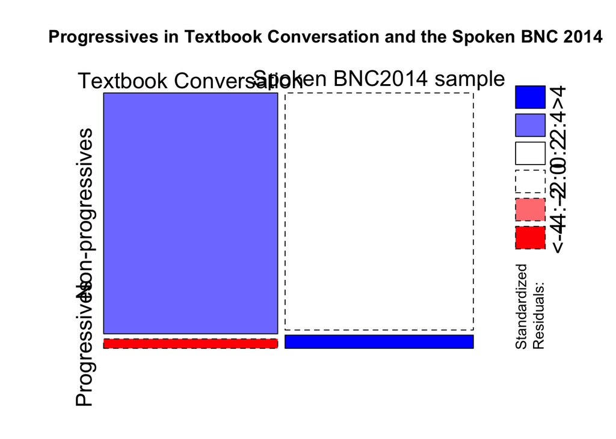

```r
# https://www.tutorialgateway.org/mosaic-plot-in-r/

#tiff(here("mosaic_prog_prop2.tiff"), height = 20, width = 30, units="cm", compression = "lzw", res = 300)

mosaicplot(prog_ratio1, shade = TRUE, main = "Progressives in Textbook Conversation and the Spoken BNC 2014", cex.axis = 1.5) # Unlike vcd::mosaic, Base R mosaicplot works with dataframes
```

```r
#dev.off()
```

# Tense, aspect and modality

```r
# Table summaries
library(gtsummary)
# Great slides on using this package: http://www.emilyzabor.com/cleveland-r-gtsummary
# Also for adding custom functions: http://www.danieldsjoberg.com/gtsummary/reference/tests.html

prog %>%
  select(Corpus, Tense) %>%
  tbl_summary(by = Corpus) %>%
  #add_p() %>%
  modify_header(label = "**Form**") #%>%
```

| **Form** | **Spoken BNC2014 sample**, N = 2,423<sup>1</sup> | **Textbook Conversation**, N = 2,423<sup>1</sup> |
| --- | --- | --- |
| Tense |  |  |
| past | 705 (29%) | 381 (16%) |
| perfect | 109 (4.5%) | 157 (6.5%) |
| present | 1,518 (63%) | 1,833 (76%) |
| modal | 91 (3.8%) | 52 (2.1%) |

<sup>*1*</sup> n (%)

```r
  #as_flex_table() %>%
  #flextable::save_as_docx(path = here("SpokenTensesTable.docx")

prog %>%
  select(Tense, Level) %>%
  tbl_summary(by = Level) %>%
  #add_p() %>%
  modify_header(label = "**Form**") #%>%
```

| **Form** | **A**, N = 316<sup>1</sup> | **B**, N = 565<sup>1</sup> | **C**, N = 622<sup>1</sup> | **D**, N = 577<sup>1</sup> | **E**, N = 343<sup>1</sup> | **Spoken BNC2014 sample**, N = 2,423<sup>1</sup> |
| --- | --- | --- | --- | --- | --- | --- |
| Tense |  |  |  |  |  |  |
| past | 1 (0.3%) | 84 (15%) | 130 (21%) | 114 (20%) | 52 (15%) | 705 (29%) |
| perfect | 0 (0%) | 3 (0.5%) | 63 (10%) | 61 (11%) | 30 (8.7%) | 109 (4.5%) |
| present | 314 (99%) | 476 (84%) | 421 (68%) | 385 (67%) | 237 (69%) | 1,518 (63%) |
| modal | 1 (0.3%) | 2 (0.4%) | 8 (1.3%) | 17 (2.9%) | 24 (7.0%) | 91 (3.8%) |

<sup>*1*</sup> n (%)

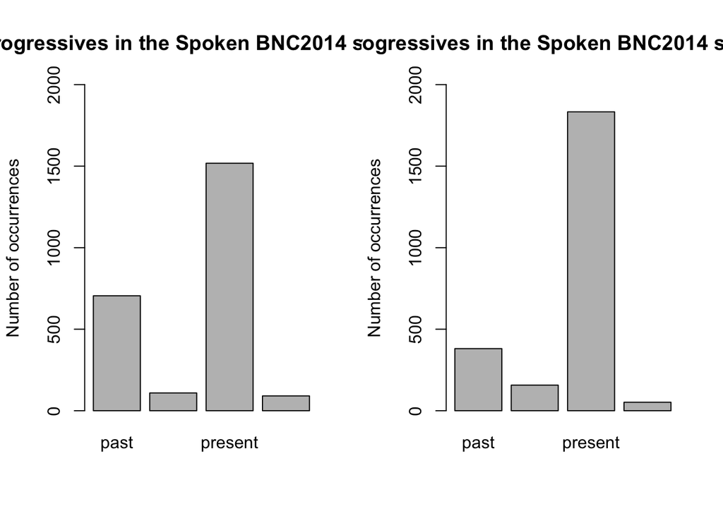

```r
  #as_flex_table() %>%
  #flextable::save_as_docx(path = here("SpokenTensesTable_byLevel.docx")

# Graphs with absolute values.
par(mfrow=c(1,2))
plot(BNCprog$Tense, main = "Progressives in the Spoken BNC2014 sample", ylab = "Number of occurrences", ylim = c(0,2000))
plot(TxBprog$Tense, main = "Progressives in the Spoken BNC2014 sample", ylab = "Number of occurrences", ylim = c(0,2000))
```

```r
par(mfrow=c(1,1))

#png(filename = here("prog_tenses.png", width = 1800, height = 1400, res = 300)

# Distributions across corpora
round(prop.table(table(prog$Tense[prog$Corpus=="Textbook Conversation"])), 4)*100
```

```
##
##    past perfect present   modal
##   15.72    6.48   75.65    2.15
```

```r
round(prop.table(table(prog$Tense[prog$Corpus=="Spoken BNC2014 sample"])), 4)*100
```

```
##
##    past perfect present   modal
##   29.10    4.50   62.65    3.76
```

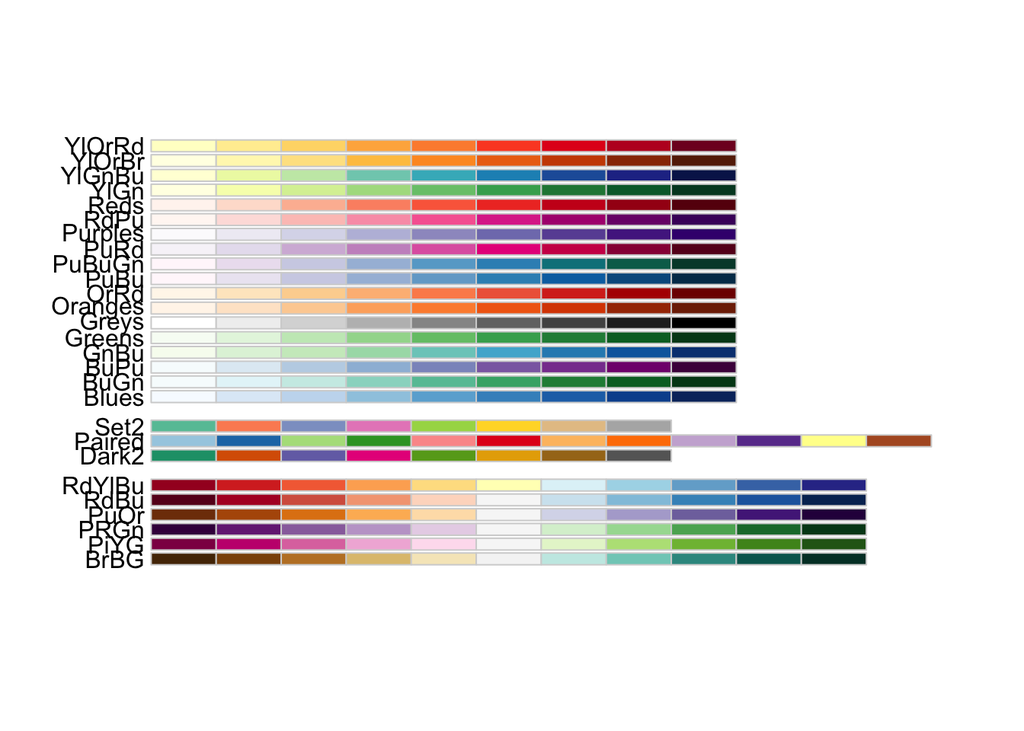

```r
# Mosaic plot of tense distribution across corpora
# Select the colours that will be used
library(RColorBrewer)
# All palette available from RColorBrewer
display.brewer.all(colorblindFriendly = T)
```

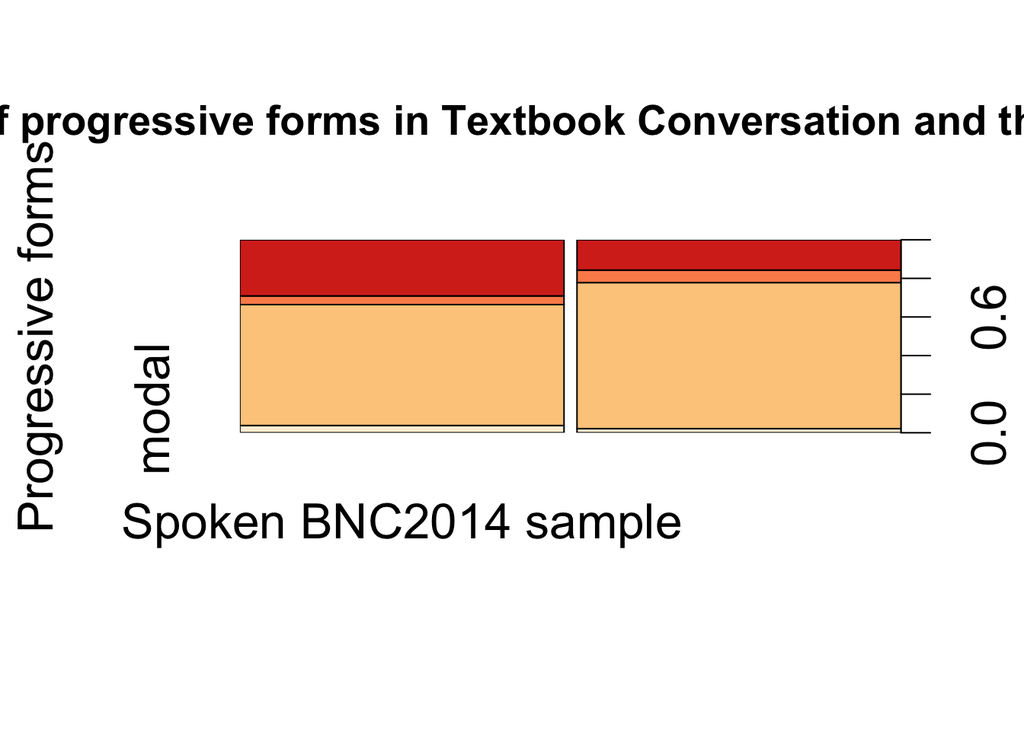

```r
# We will select the first 4 colors in the Set1 palette
cols<-brewer.pal(n=4,name="OrRd")

#tiff(here("mosaic_tenseforms.tiff"), height = 30, width = 35, units="cm", compression = "lzw", res = 300)
par(cex = 2, cex.main = 0.85, font = 2)

#svg(here("mosaic_tenseforms.svg"), height = 10, width = 12, pointsize = 12)
par(cex = 2, cex.main = 0.85, font = 2)

plot(prog$Tense ~ prog$Corpus, col = cols, xlab = "", ylab = "Progressive forms", main = "Distribution of progressive forms in Textbook Conversation and the Spoken BNC2014")
```

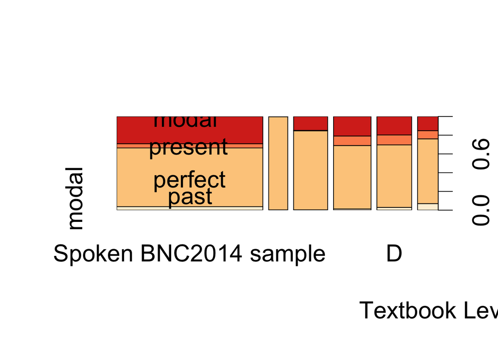

```r
#dev.off()

# Differentiated look at textbook levels #
#tiff(here("mosaic_tenseforms_levels.tiff"), height = 32, width = 40, units="cm", compression = "lzw", res = 300)
par(cex = 2)
plot(prog$Tense ~ relevel(prog$Level, "Spoken BNC2014 sample"), col = cols, xlab = "                                                   Textbook Levels", ylab = "")
#coord2 <- locator(4)
coord2 <- readRDS(file = here("coord2.rds"))
text(coord2, c("past", "perfect", "present", "modal"), font = 1)
```

```r
#dev.off()

tenses <- table(prog$Tense, prog$Corpus)
tenses
```

```
##
##           Spoken BNC2014 sample Textbook Conversation
##   past                      705                   381
##   perfect                   109                   157
##   present                  1518                  1833
##   modal                      91                    52
```

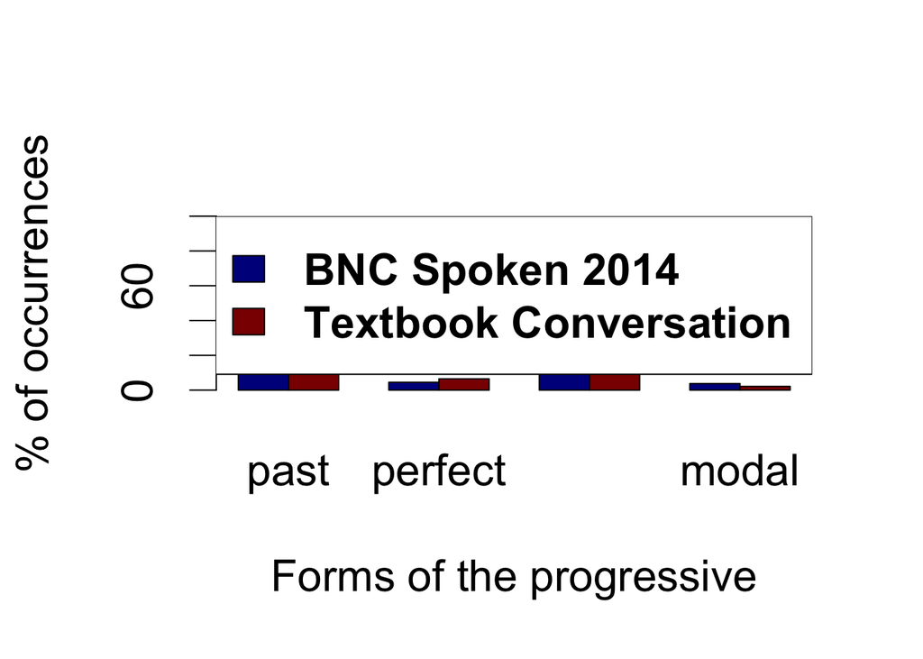

```r
tensesp <- t((prop.table(tenses, margin = 2)*100)) # Work out percentages and transpose table
tensesp <-round(tensesp, 2)

barplot(tensesp, beside = TRUE, ylab = "% of occurrences", xlab = "Forms of the progressive", ylim = c(0,100), col = c("darkblue", "darkred"))
legend("topright", fill = c("darkblue", "darkred"), c("BNC Spoken 2014", "Textbook Conversation"))
```

```r
# Legend: "Forms of the progressives in the Spoken BNC 2014 and Textbook Conversation"

vcd::assocstats(tenses) # Measuring the effect size. Cramer's V is what we're interested in (Levshina p. 217)
```

```
##                     X^2 df P(> X^2)
## Likelihood Ratio 147.29  3        0
## Pearson          145.57  3        0
##
## Phi-Coefficient   : NA
## Contingency Coeff.: 0.171
## Cramer's V        : 0.173
```

```r
#http://groups.chass.utoronto.ca/pol242/Labs/LM-3A/LM-3A_content.htm

chisq.test(tenses)
```

```
##
##  Pearson's Chi-squared test
##
## data:  tenses
## X-squared = 145.57, df = 3, p-value < 2.2e-16
```

```r
lsr::associationTest( ~ Tense + Corpus, data = prog) # Easier to interpret results
```

```
##
##      Chi-square test of categorical association
##
## Variables:   Tense, Corpus
##
## Hypotheses:
##    null:        variables are independent of one another
##    alternative: some contingency exists between variables
##
## Observed contingency table:
##          Corpus
## Tense     Spoken BNC2014 sample Textbook Conversation
##   past                      705                   381
##   perfect                   109                   157
##   present                  1518                  1833
##   modal                      91                    52
##
## Expected contingency table under the null hypothesis:
##          Corpus
## Tense     Spoken BNC2014 sample Textbook Conversation
##   past                    543.0                 543.0
##   perfect                 133.0                 133.0
##   present                1675.5                1675.5
##   modal                    71.5                  71.5
##
## Test results:
##    X-squared statistic:  145.572
##    degrees of freedom:  3
##    p-value:  <.001
##
## Other information:
##    estimated effect size (Cramer's v):  0.173
```

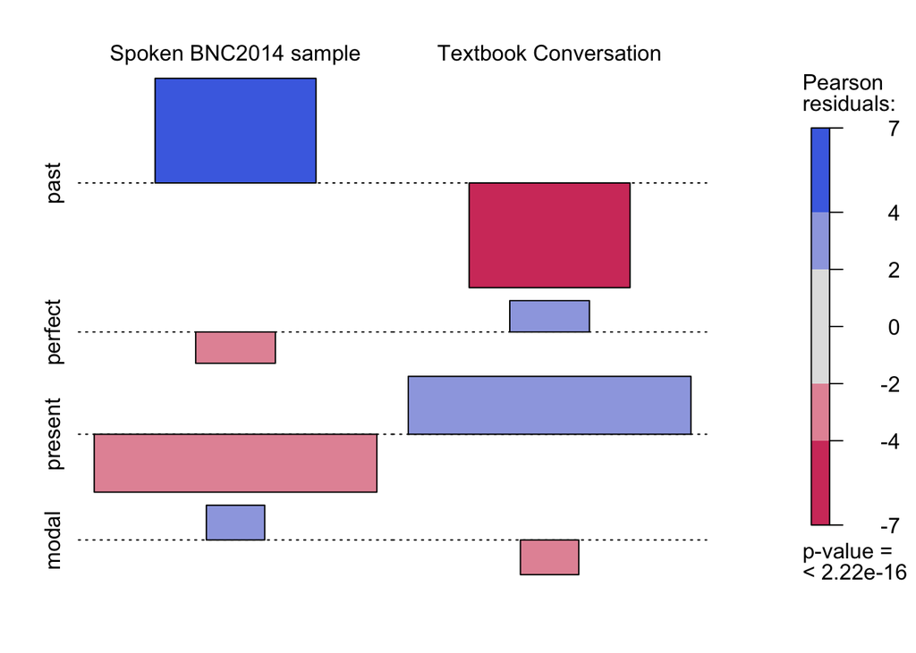

```r
# Association plot of tense distribution in corpora
#tiff(here("tenseforms_assoc.tiff"), height = 12, width = 17, units="cm", compression = "lzw", res = 300)
vcd::assoc(tenses, shade = TRUE, varnames = FALSE) # This works
```

```r
#dev.off()

chisq.test(tenses)$stdres
```

```
##
##           Spoken BNC2014 sample Textbook Conversation
##   past                11.161637            -11.161637
##   perfect             -3.027327              3.027327
##   present             -9.797030              9.797030
##   modal                3.310555             -3.310555
```

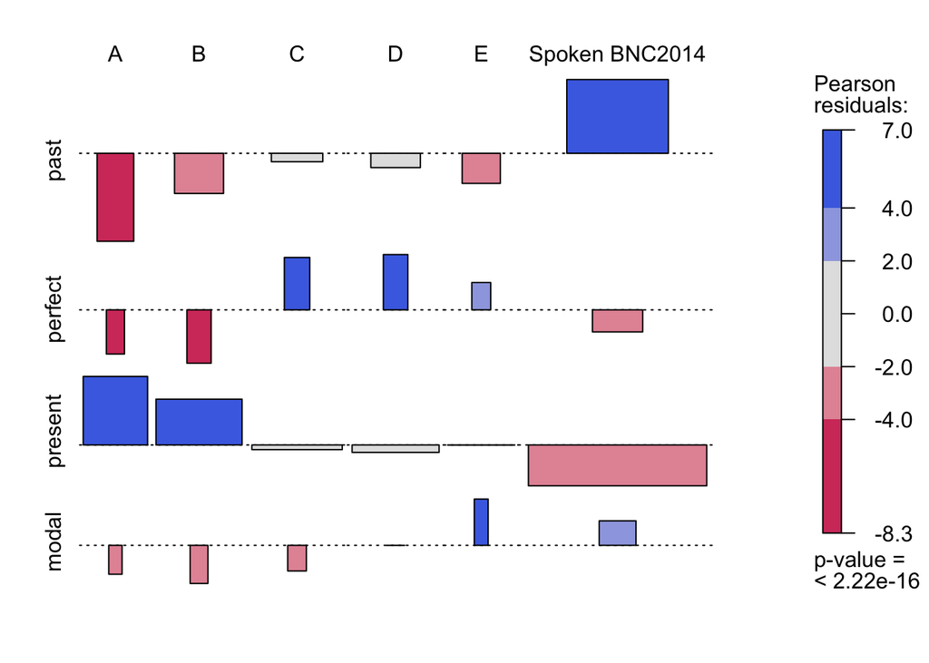

```r
# Association plot of tense distributions across levels

levels(prog$Level) <- c("A", "B", "C", "D", "E", "Spoken BNC2014")
tenselevel <- table(prog$Tense, prog$Level)

#tiff(here("tenseforms_levels_assoc.tiff"), height = 13, width = 20, units="cm", compression = "lzw", res = 300)
vcd::assoc(tenselevel, shade = TRUE, varnames = FALSE) # This works
```

```r
#dev.off()

lsr::associationTest( ~ Tense + Level, data = prog) # Easier to interpret results
```

```
##
##      Chi-square test of categorical association
##
## Variables:   Tense, Level
##
## Hypotheses:
##    null:        variables are independent of one another
##    alternative: some contingency exists between variables
##
## Observed contingency table:
##          Level
## Tense        A    B    C    D    E Spoken BNC2014
##   past       1   84  130  114   52            705
##   perfect    0    3   63   61   30            109
##   present  314  476  421  385  237           1518
##   modal      1    2    8   17   24             91
##
## Expected contingency table under the null hypothesis:
##          Level
## Tense          A     B     C     D     E Spoken BNC2014
##   past     70.82 126.6 139.4 129.3  76.9          543.0
##   perfect  17.35  31.0  34.1  31.7  18.8          133.0
##   present 218.51 390.7 430.1 399.0 237.2         1675.5
##   modal     9.32  16.7  18.4  17.0  10.1           71.5
##
## Test results:
##    X-squared statistic:  373.529
##    degrees of freedom:  15
##    p-value:  <.001
##
## Other information:
##    estimated effect size (Cramer's v):  0.16
```